# The Genetic Algorithm of GMSE

GMSE: an R package for generalised management strategy evaluation (Supporting Information 1)

A. Bradley Duthie¹³, Jeremy J. Cusack¹, Isabel L. Jones¹, Jeroen Minderman¹, Erlend B. Nilsen², Rocío A. Pozo¹, O. Sarobidy Rakotonarivo¹, Bram Van Moorter², and Nils Bunnefeld¹’

[2] Norwegian Institute for Nature Research, Trondheim, Norway [3] alexander.duthie@stir.ac.uk

# Extended introduction to the genetic algorithm applied in GMSE

Game theory is the formal study of strategic interactions, and can therefore be applied to modelling stakeholder actions and addressing issues of cooperation and conflict in conservation (Lee 2012; Kark et al. 2015; Adami, Schossau, and Hintze 2016; Tilman, Watson, and Levin 2016; Redpath et al. 2018). In game-theoretic models, agents adopt strategies to make decisions that maximise some type of payoff (e.g., utility, biological fitness). Agents are constrained in their decision-making, and realised pay-offs depend on decisions made by other agents. In simple models, it is often useful to assume that agents are perfectly rational decision-makers, then find optimal solutions for pay-off maximisation mathematically. But models that permit even moderately complex decision-making strategies or pay-off structures often include more possible strategies than are mathematically tractable (Hamblin 2013). In these models, genetic algorithms, which mimic the process of natural selection (mutation, recombination, selection, reproduction), can find adaptive (i.e., practical, but not necessarily optimal) solutions for game strategies (e.g., Balmann and Happe 2000; Tu, Wolff, and Lamersdorf 2000; Hamblin 2013).

# Key data structures used

The focal data structure used for tracking manager and user decisions is a three dimensional array, which we will call `ACTION` (also returned as `user_array` by `gmse_apply`; see SI7). Rows of `ACTION` correspond to the entities affected by actions (resources, landscape properties, or potentially other agents), and columns correspond either to properties of the affected entities, or to the actions potentially allocated to them. Each layer of `ACTION` corresponds to a unique agent, the first of which is the manager; additional layers correspond to users. Below shows an `ACTION` array for a GMSE model with one manager and two users.

```
## , , Manager_Actions
##
##           Act Type_1 Type_2 Type_3      Util. U_land U_loc. Scare Cull Castrate
## Resource   -2      1      0      0 1000.00000      0      0     0    0        0
## Landscape  -1      1      0      0    0.00000      0      0     0    0        0
## Res_cost    1      1      0      0  -65.75964      0      0    10   42       10
## U1_cost     2      1      0      0    0.00000      0      0     0    0        0
## U2_cost     3      1      0      0    0.00000      0      0     0    0        0
##           Feed Help_off None
## Resource     0        0    0
## Landscape    0        0    0
## Res_cost    10       10   78
## U1_cost      0        0    0
## U2_cost      0        0    0
##
## , , User_1_Actions
##
##           Act Type_1 Type_2 Type_3 Util. U_land U_loc. Scare Cull Castrate Feed
## Resource   -2      1      0      0    -1      0      0     0   23        0    0
## Landscape  -1      1      0      0     0      0      0     0    0        0    0
## Res_cost    1      1      0      0     0      0      0     0    0        0    0
## U1_cost     2      1      0      0     0      0      0     0    0        0    0
## U2_cost     3      1      0      0     0      0      0     0    0        0    0
##           Help_off None
## Resource         0    1
## Landscape        0    2
## Res_cost         0    0
## U1_cost          0    0
## U2_cost          0    0
##
## , , User_2_Actions
##
##           Act Type_1 Type_2 Type_3 Util. U_land U_loc. Scare Cull Castrate Feed
## Resource   -2      1      0      0    -1      0      0     0   23        0    0
## Landscape  -1      1      0      0     0      0      0     0    0        0    0
## Res_cost    1      1      0      0     0      0      0     0    0        0    0
## U1_cost     2      1      0      0     0      0      0     0    0        0    0
## U2_cost     3      1      0      0     0      0      0     0    0        0    0
##           Help_off None
## Resource         0    0
## Landscape        0    1
## Res_cost         0    0
## U1_cost          0    0
## U2_cost          0    0
```

The above array holds all of the information on manager and user actions. The first seven columns contain information about which entities are affected, and how they are affected. The first column `Act` identifies the type of action being performed; a value of -2 defines a direct action to a resource (e.g., culling of the resource), and a value of -1 defines direct action to a landscape (e.g., increasing yield). Positive values are currently only meaningful for `Manager_Actions`, where a value of 1 defines an action setting a uniform cost of users’ direct actions on resources (i.e., costs where `Act = -2` for `User_1_Actions` and `User_2_Actions`). All other values for `Act` are meaningless in GMSE 0.6, but might be expanded upon in future versions to allow for modification of specific user costs enacted by managers (i.e., managers having different policies for different users) or other users (e.g., users increasing the costs of other users’ actions due to conflict or cooperation). We will therefore focus only on rows 1-3 of `ACTION`.

Columns 2-4 refer to resource or landscape types, but only `Type_1 = 1`, `Type_2 = 0`, and `Type_3 = 0` are allowed in predefined GMSE v0.6 manager and user sub-models (i.e., only one type of resource is permitted). Future versions might allow for different resource types (e.g., `Type_1` might be used to designate species, and `Type_2` and `Type_3` could designate stage or sex). Column 5 `Util.` of `ACTION` defines the utility associated with the resource (where `Act = -2`) or landscape (where `Act = -1`). For managers, the target resource abundance set with the GMSE argument `manage_target` is found in row 1 (1000 in `ACTION` above); for users, the value in row 1 identifies whether resources are preferred to increase (if positive) or decrease (if negative). Values of column 5 in row 2 similarly identify whether landscape cell output is preferred by users to increase or decrease (managers do not currently have preferences for landscape output). Of special note is row 3 for `Manager_Actions`, which defines the *current* manager’s utility for resources; that is, the adjustment to resource abundance that the manager will attempt to make based on the `manage_target` and the most recent estimate of resource abundance produced by the observation model (in the case of the above, resource abundance is estimated at ca 1065.76, so the manager will set policy in attempt to change the population size by ca -65.76 resources). Column 6 `U_land` defines whether or not the utility attached to the resource or landscape output depends on it being on a landscape cell that is owned by the acting user. Related, column 7 `U_loc.` defines whether or not actions can be performed only on a landscape cell that is owned by the acting user. Hence values of columns 6 and 7 are binary, and affected by the `land_ownership` argument in `gmse` and `gmse_apply`. Finally, columns 8-13 correspond to specific actions, either direct (where `Act < 0`) or indirect by setting policy (for row 3 of `Manager_Actions` where `Act = 1`). The last column 13 `None` corresponds with no actions. See [GMSE documentation](https://cran.r-project.org/web/packages/GMSE/GMSE.pdf) for details about the effects of each action.

Constraints on the values that elements in the `ACTION` array can take are defined by a `COST` array (also returned as `manager_array` by `gmse_apply`; see SI7) of dimensions identical to `ACTION`. Elements of `COST` define how many units from the `manager_budget` or `user_budget` are needed to perform a single action; a `minimum_cost` for actions is defined as an argument in GMSE (10 by default). All values in `COST` columns 1-7 are set to 100001, one higher than the highest possible `manager_budget` or `user_budget`, so neither managers nor users can affect resource types or utilities. Columns 8-13 are also set to 100001, except where actions are allowed. Maximum values of 100000 are independent of any other parameter value specified in GMSE (e.g., landscape dimensions). Below shows the `COST` array that corresponds to the above `ACTION` array.

```
## , , Manager_Costs
##
##              Act Type_1 Type_2 Type_3  Util. U_land U_loc.  Scare   Cull
## Resource  100001 100001 100001 100001 100001 100001 100001 100001 100001
## Landscape 100001 100001 100001 100001 100001 100001 100001 100001 100001
## Res_cost  100001 100001 100001 100001 100001 100001 100001 100001     10
## U1_cost   100001 100001 100001 100001 100001 100001 100001 100001 100001
## U2_cost   100001 100001 100001 100001 100001 100001 100001 100001 100001
##           Castrate   Feed Help_off   None
## Resource    100001 100001   100001     10
## Landscape   100001 100001   100001     10
## Res_cost    100001 100001   100001     10
## U1_cost     100001 100001   100001 100001
## U2_cost     100001 100001   100001 100001
##
## , , User_1_Costs
##
##              Act Type_1 Type_2 Type_3  Util. U_land U_loc.  Scare   Cull
## Resource  100001 100001 100001 100001 100001 100001 100001 100001     42
## Landscape 100001 100001 100001 100001 100001 100001 100001 100001 100001
## Res_cost  100001 100001 100001 100001 100001 100001 100001 100001 100001
## U1_cost   100001 100001 100001 100001 100001 100001 100001 100001 100001
## U2_cost   100001 100001 100001 100001 100001 100001 100001 100001 100001
##           Castrate   Feed Help_off   None
## Resource    100001 100001   100001     10
## Landscape   100001 100001   100001     10
## Res_cost    100001 100001   100001 100001
## U1_cost     100001 100001   100001 100001
## U2_cost     100001 100001   100001 100001
##
## , , User_2_Costs
##
##              Act Type_1 Type_2 Type_3  Util. U_land U_loc.  Scare   Cull
## Resource  100001 100001 100001 100001 100001 100001 100001 100001     42
## Landscape 100001 100001 100001 100001 100001 100001 100001 100001 100001
## Res_cost  100001 100001 100001 100001 100001 100001 100001 100001 100001
## U1_cost   100001 100001 100001 100001 100001 100001 100001 100001 100001
## U2_cost   100001 100001 100001 100001 100001 100001 100001 100001 100001
##           Castrate   Feed Help_off   None
## Resource    100001 100001   100001     10
## Landscape   100001 100001   100001     10
## Res_cost    100001 100001   100001 100001
## U1_cost     100001 100001   100001 100001
## U2_cost     100001 100001   100001 100001
```

Note that in default GMSE parameters, `culling = TRUE`, but all other actions are set to `FALSE`. Hence, the `Cull` column 9 is the only column besides column 13 `None` in which cost is less than 100001. Manager’s actions in `ACTION` directly affect the cost of users performing one of the five possible actions on resources (columns 8-12). This can be verified in `ACTION` where the manager has set the cost of culling to 42 (row 3), and the corresponding `COST` of resource culling is 42 for both users (row 1). The cost of the manager affecting the cost of user actions is always set to the `minimum_cost`; here the default 10 is used. This `minimum_cost` also defines cost values for `None`, in which the user or manager does nothing, as might occur if the manager wants to permit culling and therefore does not want to invest any of their `manager_budget` to increasing the cost of culling. Both `ACTION` and `COST` are updated in each time step unless `manage_freq > 1`, in which case `COST` and `Manager_Actions` in `ACTION` are updated at the frequency defined.

# General overview of key aspects of the genetic algorithm

The genetic algorithm updates a single layer of the `ACTION` array, which defines the decisions of a single agent (either the manager or a user). The corresponding layer of the `COST` array remains unchanged, and serves only to ensure that `ACTION` values do not exceed `manager_budget` or `user_budget` for managers and users, respectively. The genetic algorithm proceeds by first initialising a large (but temporary) population of new `ACTION` layers. In each iteration, these layers crossover and mutate, generating variation in potential agent decisions; costs constrain this variation from exceeding a maximum budget, then the fitness of each layer is evaluated based on how the layer is predicted to affect resources or landscape output to which the agent has assigned some utility. A tournament is used to select high fitness layers, and these selected layers become the new iteration of layers; iterations continue until a minimum number of iterations (`ga_mingen`) have passed and a convergence criteria is satisfied such that the increase in mean fitness from the previous iteration is below the threshold `converge_crit` (Figure 1 below).

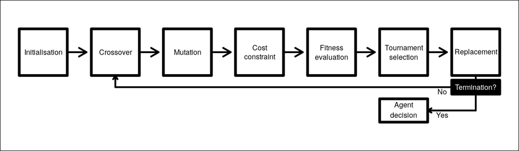

Conceptual overview of the GMSE genetic algorithm

## Initialisation

At the start of each genetic algorithm, a population of size `ga_popsize` is initialised (hereafter the `POPULATION` array). This population is held in a 3D array of `ga_popsize` layers. Each layer includes an identical number of rows and columns as in `ACTION`, and one layer defines a single ‘individual’ in the population. The first seven columns of `ACTION` are replicated exactly for all individuals, and remain unchanged throughout the genetic algorithm thereby preserving the information about which entities are affected by actions in a given row. The remaining columns are either also replicated exactly as in `ACTION` (i.e., initialised to be the same decisions as in a previous time step), or randomly seeded with values given the constraints of `manager_budget` or `user_budget` (i.e., initialised to random decision making). The number of exact replicates initialised is set using `ga_seedrep` (if `ga_seedrep` $\geq$ `ga_popsize`, then all individuals are seeded as replicates). After the `POPULATION` of `ga_popsize` individuals is initialised, a loop simulating the adaptive evolution of `POPULATION` in non-overlapping iterations begins (see Figure 1 above).

## Crossover

A single iteration of the genetic algorithm begins with a uniform crossover (Hamblin 2013), by which actions of individuals in `POPULATION` are randomly swapped with some probability. To implement crossover, each individual selects a partner, then exchanges corresponding array elements affecting agent actions (columns 8-13) with their partner at a fixed probability of `ga_crossover`.

## Mutation

Following crossover, `POPULATION` array elements affecting agent actions (columns 8-13) mutate at a fixed probability of `ga_mutation`. For each array element, a random uniform number $u \in [0, 1]$ is sampled. If $u$ is greater than `1 - (0.5 * ga_mutation)`, then the value of the array element is increased by 1. If $u$ is less than `0.5 * ga_mutation`, then the value of the array element is decreased by 1; when this decrease results in a negative value, the mutated value is multiplied by -1 to be positive.

## Cost constraint

Variation in manager or user actions generated by crossover and mutation might result in strategies that exceed `manager_budget` or `user_budget`, respectively. Left unchecked, this over-budgeting could lead to unnacceptably high fitness strategies, so strategies that are over budget following crossover and mutation need to be brought back within budgetary constraints. To do this, the genetic algorithm first checks to see if an individual in `POPULATION` is over budget. If so, then an action is randomly selected and removed, and budget use is reassessed; this random removal of an action and subsequent budget reassessment continues until the individual does not exceed their budget.

## Fitness evaluation

Once all individuals in `POPULATION` are within budget, the fitness of each individual is assessed. Fitness assessment works differently for managers versus users because managers need to consider the consequences of their decisions on user actions, and how those actions will affect resource abundance. In contrast, user actions need to consider the consequences of their decisions on resource abundance or landscape output. Individual fitness is defined by a real number that increases with the degree to which an individual’s actions are predicted to increase entities of positive utility and decrease entities of negative utility (recall that managers and users assign resources or landscape output a utility value). Details for how fitness is calculated are provided below.

## Replacement and termination

Once a new set of `ga_popsize` individuals is retained through tournament selection, these individuals replace the previous `POPULATION` array. The genetic algorithm terminates if and only if a minimum number of iterations has passed (`ga_mingen`) and a convergence criteria (`converge_crit`) is satisfied. The convergence criteria checks the difference between the mean fitness of individuals in the new iteration versus the previous iteration; if this difference is greater than `converge_crit`, then termination does not occur (this prevents termination from occuring while fitness is still increasing, though it is usually fine to use the default GMSE `converge_crit = 0.1` and `ga_mingen = 40`, which nearly always terminates the genetic algorithm after 40 iterations having identified adaptive manager or user strategies). Due to the way in which fitness is calculated (see below), in practice, `converge_crit` currently applies only to users. If termination conditions are not satisfied, then the `POPULATION` of individuals begins a new iteration of crossover, mutation, cost constraint, fitness evaluation, and tournament selection (Figure 1).

# Detailed explanation of manager and user fitness functions

Here we explain how the fitnesses of candidate manager and user strategies in a `POPULATION` array (see above) are calculated. We emphasise that the fitness functions used in GMSE v0.6 are intended to be heuristic tools for identifying reasonable manager and user behaviours. In practice, our fitness functions identify behaviours that are well-aligned with manager and user interests for harvesting or crop yield, but they are not intended to identify *optimal* decisions. This practical, metaheuristic approach is consistent with the objectives of management strategy evaluation (Bunnefeld, Hoshino, and Milner-Gulland 2011), and is well-suited for the use of genetic algorithms (Hamblin 2013). Luke (2009) describes the metaheuristic approach more generally (original emphasis retained):

> Metaheuristics are applied to *I know it when I see it* problems. They’re algorithms used to find answers to problems when you have very little to help you: you don’t know beforehand what the optimal solution looks like, you don’t know how to go about finding it in a principled way, you have very little heuristic information to go on, and brute-force search is out of the question because the space is too large. *But* if you’re given a candidate solution to your problem, you *can* test it and assess how good it is. That is, you know a good one when you see it.

Given the complexity of adaptive management and socio-ecological interactions, the above conditions for applying the metaheuristic approach are clearly satisfied for manager and user decisions. With this in mind, we now explain the details of manager and user fitness functions; that is, how GMSE assesses whether or not a strategy is a good one.

## Fitness function for managers

Individual fitness as calculated for managers ($F_{i}^{m}$) is affected by a manager’s utility for resources and the projected change in resource abundance caused by the individual’s policy (i.e., the contents of their `POPULATION` layer, specifically row 3; here again we use ‘individual’ to refer to one of `ga_popsize` discrete strategies in `POPULATION`, which may be selected and reproduce within the genetic algorithm). Manager utility for a resource ($U^{m}_{res}$) is defined as the difference between `manage_target` and the estimation of population abundance as produced by the GMSE observation model (see “Key data structures used” above, and SI7 for more information). Manager utility can therefore change in each GMSE time step as estimated resource abundance changes; when the estimated resource abundance is greater than `manage_target`, $U^{m}_{res}$ is negative, and when the estimated resource abundance is less than `manage_target`, $U^{m}_{res}$ is positive. To get the fitness of individuals, first the change in resource abundance predicted by the individual’s policy ($\Delta A_{i}$) is calculated, then the squared difference between $\Delta A_{i}$ and $U^{m}_{res}$ is calculated to obtain a utility deviation ($D_{i}$) for the individual $i$,

$$D_{i} = (\Delta A_{i} - U^{m}_{res})^2.$$

The value of $D_{i}$ increases as $\Delta A_{i}$ gets further from $U^{m}_{res}$; i.e, $D_{i}$ is high when $i$ sets a policy that is not predicted to get closer to the `manage_target` abundance. Fitness is defined by first finding the maximum $D_{i}$ value among all `ga_popsize` individuals ($D_{max}$), then subtracting $D_{i}$ from this value for each individual,

$$F^{m}_{i} = D_{max} - D_{i}.$$

We have explained how $U^{m}_{res}$ is calculated in the above section on key data structures. We now explain in more detail how individuals in the genetic algorithm calculate how their actions will affect $\Delta A_{i}$.

To predict change in resource abundance as a consequence of policy, an individual first needs to know the total number of actions of all types $j$ (e.g., scaring, culling, etc.) performed by users in the previous time step ($X_{\bullet, j}$; note that this value includes the increment `manage_caution`, with a default of `manage_caution = 1`, to ensure that managers do not naïvely assume that users will not perform an action just because they did not perform it in the previous time step), and the cost of performing each action ($C_{\bullet, j}$). This information is collected from `ACTION` and `COST` arrays. The individual $i$ then needs to predict how their policy (i.e., the costs that they set for users to perform an action) will affect the new total number of each action $j$ performed ($X_{i,j}$). To do this, the individual assumes that total user actions performed under their policy will change in proportion to that of the old policy, while also recognising that users have a maximum above which higher costs set by the manager will have no effect. Interested readers might wish to examine the short [`new_act`](https://github.com/bradduthie/gmse/blob/master/src/game.c#L452) function, which is summarised mathematically below; this function is called by the [`policy_to_counts`](https://github.com/bradduthie/gmse/blob/master/src/game.c#L482) function in the [genetic algorithm source file](https://github.com/bradduthie/gmse/blob/dev/src/game.c).

The manager first calculates how much total budget, as summed over all users, was devoted to an action by multiplying the old per action cost $C_{\bullet, j}$ by the total number of actions performed, $X_{\bullet, j}$. The manager then divides this by the new cost $C_{i, j}$ per action to calculate the new predicted number of actions,

$$X_{i, j} = \frac{X_{\bullet, j} \times C_{\bullet, j}}{C_{i, j}}.$$

Note again that if $C_{i, j} = C_{\bullet, j}$, then the total number of new predicted actions $j$ will remain unchanged. If $C_{i, j} > C_{\bullet, j}$, then the total number of new actions will decrease, and if $C_{i, j} < C_{\bullet, j}$, then the total number of new actions will increase.

The predicted consequences of $X_{i,j}$ for resource abundance differ for each possible action. For each action, no consequence is predicted if the policy is not allowed by a simulation of GMSE (e.g., `culling = FALSE`). For allowed actions, the parameter `manager_sense` ($\sigma$) modulates predicted consequences for abundance by some factor; this is useful because not all actions attempted by users will be realised, and a value of $\sigma = 1$ tends to slightly overestimate how much the actions attempted by users will actually translate to a change in resource abundance. In practice, the default $\sigma = 0.9$ usually performs well. Managers also have access to an estimate of the number of offspring that resources produce ($E[offspring]$). For default settings in GMSE v0.6, $E[offspring] = \lambda$, where $\lambda$ is the GMSE argument `lambda` that defines the baseline population growth rate of resources. Given a non-default GMSE argument for `consume_repr` (where `consume_repr` is how much consumption of landscape yield is needed to increment offspring production by 1), $E[offspring]$ is further incremented by `( (times_feeding * res_consume) / consume_repr)` to account for reproduction enabled by feeding on the landscape (`res_consume` is the proportion of landscape yield that a resource consumes during feeding).

Allowed actions are predicted by managers to have the following effects (again, we emphasise that whether or not these effects are realised will depend later on the user model, to which the manager – by design – does not have access):

- `scaring` is assumed to be nonlethal and therefore have no effect on resource number (resources are moved to a random cell on the landscape, as sampled from a uniform distribution such that movement to any given cell is equally probable).
- `culling` decreases resource number by $\sigma (1 + E[offspring])$.
- `castration` decreases resource number by $\sigma (E[offspring])$.
- `feeding` increases resource number by $\sigma (E[offspring])$.
- `help_offspring` increases resource number by $\sigma$.

Note that $\sigma$ is included in all of the predicted actions above as a modulator for how strongly the manager predicts users will respond to a change in manager policy (e.g., a value of 0 would predict no reaction on the part of users to a change in policy, while a value of 1 would predict that an action would increase in exact proportion to its decrease in cost).

The above effects cannot be altered directly in `gmse` or `gmse_apply` (though parameter values can of course be changed using `manager_sense` and arguments affecting $E[offspring]$), but future versions of GMSE might include different predicted effects to increase precision or allow for multiple resource types or different actions. The summation of $X_{i,j}$ for all actions defines the predicted change in resource abundance caused by the policy of an individual $i$, $\Delta A_{i}$.

## Fitness function for users

The previous section described the fitness function applied when individual’s fitness was evaluated for managers; here we explain a separate fitness function that is applied when individuals are instead evaluated for users. Individual fitness as calculated for users ($F_{i}^{u}$) is affected by a user’s utility for resources ($U^{u}_{res}$) and landscape output ($U^{u}_{land}$), and the predicted change in each caused by the user’s actions ($\Delta A_{i}$ and $\Delta L_{i}$ for predicted change in resource abundance and summed values of the landscape cells owned by $i$, respectively). Individual fitness is defined for users below,

$$F_{i}^{u} = \Delta A_{i} U^{u}_{res} + \Delta L_{i} U^{u}_{land}.$$

Note that $F_{i}^{u}$ increases when $\Delta A_{i}$ and $\Delta L_{i}$ are of the same sign as $U^{u}_{res}$ and $U^{u}_{land}$, respectively. Further, in GMSE v0.6, only one term of the equation is nonzero. When `land_ownership = FALSE` (default, modelling users that harvest resources), $U^{u}_{res} = -1$ and $U^{u}_{land} = 0$, and when `land_ownership = TRUE`, $U^{u}_{res} = 0$ and $U^{u}_{land} = 100$ (modelling farmers trying to increase crop yield). Hence users only have a single objective of either decreasing resource abundance or increasing landscape output, though landscape output might be increased indirectly by decreasing resource abundance if `res_consume > 0`.

Unlike the manager fitness function, the predicted effects of user actions can be defined directly in `gmse` and `gmse_apply`. Hence, it is possible to specify how effective a user believes, e.g., culling or scaring to be with respect to their own utility. Arguments to do this include `perceive_scare`, `perceive_cull`, `perceive_cast`, `perceive_feed`, `perceive_help`, `perceive_tend` and `perceive_kill`. Each of these arguments define how much a user believes one action will affect either the user or the landscape. For example, if `perceive_scare = -1`, then a user will perceiving scaring as decreasing the number of resources feeding on their landscape by 1. A value of `perceive_feed = 0.5` would correspond to a user perceiving feeding to increase the number of resources by one half. Landscape effects (`perceive_tend` and `perceive_kill`) refer to effects of actions on the landscape, such that `perceive_tend = 0.2` would mean that a single action of tending crops (i.e., action taken on a single landscape cell) is perceived to increase crop yield by 0.2, while `perceive_kill = -1` would mean that a single action of killing crops will remove all yield on the landscape cell.

The number of each action performed is multiplied by its effect, and the sum of all these products is the predicted $\Delta A_{i}$,

$$\Delta A_{i} = (\lambda) Feeds + Helps -Scares - Culls - (\lambda) Castrations.$$

There are only two possible actions that users can take to directly affect landscape output, tending crops (`tend_crops`) and killing crops (`kill_crops`). The increase in landscape output is modulated by the parameter `tend_crop_yld` ($\phi$). User actions are therefore predicted to have the following effects for one landscape cell:

- `tend_crops` will increase landscape output by $\phi$ (i.e., `perceive_tend = tend_crop_yld`).
- `kill_crops` will decrease landscape output by 1 (since the output of a cell is 1 by default, this action removes all output on a landscape cell; i.e., `perceive_kill = -1`).

Actions on resources can also have indirect effects on $\Delta L_{i}$ when resources consume output on the landscape; we define the value `res_consume` as $r$. The predicted $\Delta L_{i}$ is then,

$$\Delta L_{i} = (\phi)Tends - Kills - r\Delta A_{i}.$$

That is, the change in landscape output equals the increase in output from tending crops, minus the number of crops destroyed, minus the change in resource abundance times the effect that resource abundance has on landscape output (note that if user actions decrease resource abundance, then this last term will be positive, increasing landscape output).

## Choosing genetic algorithm parameter values

Options for adjusting genetic algorithm parameter values in `gmse` and `gmse_apply` are shown below.

[output not shown]

Given the heuristic goals of the genetic algorithm to mimic the goal-oriented behaviour of agents, default parameters are typically sufficient for agent decision making. Key parameters can be adjusted if more precision in decision making is desired, but these adjustments will come at a cost of simulation efficiency. For example, increasing `ga_popsize` or `ga_mingen`, or decreasing `ga_converge_crit`, might fine tune strategies more effectively, but this will cause the genetic algorithm to take longer every time that it is run, ultimately slowing down GMSE simulations. Alternativey, setting `group_think = TRUE` will greatly speed up GMSE simulations when many users are being simulated, but this comes at the cost of among-user variation in decision making. Overall, we recommend first using default values in the genetic algorithm before exploring how other parameter value options affect simulation dynamics; for a more general discussion about selecting parameter values in genetic algorithms, see Hamblin (2013).

## Future development of fitness functions

The fitness functions defined above are useful heuristics for simulating manager and user decision-making in a way that produces realistic, *I know it when I see it*, strategies. Future versions of GMSE might improve upon these heuristics to generate more accurate or more realistic models of human decision making. Such improvements could incorporate additional information such as memory of actions from multiple past time steps, or a continually updated estimate for how actions are predicted to affect resource abundance or landscape output in a simulation (e.g., through a dynamic `manager_sense`). Alternatively, future improvements could usefully incorporate knowledge of human decision making collected from empirical observation of human behaviour during conservation conflicts. While such possibilities could be useful for future GMSE modelling, repeated simulations demonstrate the ability of the current GMSE genetic algorithm to find adaptive strategies for managers attempting to keep resources at target abundance, and users attempting to maximise their harvests or crop yields. It is therefore useful as a tool for modelling manager and user decisions in a generalised management strategy evaluation framework.

# References

Adami, Christoph, Jory Schossau, and Arend Hintze. 2016. “Evolutionary game theory using agent-based methods.” *Physics of Life Reviews* 19. Elsevier B.V.: 1–26. https://doi.org/10.1016/j.plrev.2016.08.015.

Balmann, A, and K Happe. 2000. “Applying parallel genetic algorithms to economic problems: The case of agricultural land markets.” In *IIFET Conference “Microbehavior and Macroresults”. Proceedings.* Corvallis, Oregon, USA. http://oregonstate.edu/dept/IIFET/2000/papers/balmann2.pdf.

Bunnefeld, Nils, Eriko Hoshino, and Eleanor J Milner-Gulland. 2011. “Management strategy evaluation: A powerful tool for conservation?” *Trends in Ecology and Evolution* 26 (9): 441–47. https://doi.org/10.1016/j.tree.2011.05.003.

Hamblin, Steven. 2013. “On the practical usage of genetic algorithms in ecology and evolution.” *Methods in Ecology and Evolution* 4 (2): 184–94. https://doi.org/10.1111/2041-210X.12000.

Kark, Salit, Ayesha Tulloch, Ascelin Gordon, Tessa Mazor, Nils Bunnefeld, and Noam Levin. 2015. “Cross-boundary collaboration: Key to the conservation puzzle.” *Current Opinion in Environmental Sustainability* 12. Elsevier B.V.: 12–24. https://doi.org/10.1016/j.cosust.2014.08.005.

Lee, Chih Sheng. 2012. “Multi-objective game-theory models for conflict analysis in reservoir watershed management.” *Chemosphere* 87 (6). Elsevier Ltd: 608–13. https://doi.org/10.1016/j.chemosphere.2012.01.014.

Luke, Sean. 2009. *Essentials of Metaheuristics*. Lulu.

Redpath, Steve M, Aidan Keane, Henrik Andrén, Z Baynham-Herd, Nils Bunnefeld, A Bradley Duthie, J Frank, et al. 2018. “Games as Tools to Address Conservation Conflicts.” *Trends in Ecology and Evolution* 33 (6): 415–26. https://doi.org/10.1016/j.tree.2018.03.005.

Tilman, Andrew R., James R. Watson, and Simon Levin. 2016. “Maintaining cooperation in social-ecological systems:” *Theoretical Ecology*. Theoretical Ecology. https://doi.org/10.1007/s12080-016-0318-8.

Tu, M Tuan, Eberhard Wolff, and Winfried Lamersdorf. 2000. “Genetic algorithms for automated negotiations: a FSM-based application approach.” *Proceedings 11th International Workshop on Database and Expert Systems Applications*, 1029–33. https://doi.org/10.1109/DEXA.2000.875153.